# R Notebook

# This is for the latest 2019 PLANEA test!

Let’s define some function to interact easily with the database.

```r
plan_connect <- function(){
  DBI::dbConnect(RPostgreSQL::PostgreSQL(),
  host     =  "localhost",
  user     =  "planea",
  password =  "planea",
  port     =  5432,
  dbname   =  "planea")
}

load_query <- function(connection,schema,the_table,columns="*",options=""){
    the_query <- "SELECT %s FROM %s.%s"
    complete <- paste0(the_query," ",options)
    schema    <- deparse(substitute(schema))
    the_table <- deparse(substitute(the_table))
    initial <- RPostgreSQL::dbSendQuery(connection,
                             sprintf(complete,columns,schema,the_table))
    return(initial)
}

load_table <- function(connection,schema,the_table){
    the_query <- "SELECT * FROM %s.%s"
    schema    <- deparse(substitute(schema))
    the_table <- deparse(substitute(the_table))
    initial <- RPostgreSQL::dbSendQuery(connection,
                             sprintf(the_query,schema,the_table))
}

large_table <- function(connection,schema,the_table){
    schema    <- deparse(substitute(schema))
    the_table <- deparse(substitute(the_table))
    retrieved <- dplyr::tbl(connection,dbplyr::in_schema(schema,the_table))
    return(retrieved)
}

clear_results <- function(connection){
    DBI::dbClearResult(DBI::dbListResults(connection)[[1]])
}

retrieve_result <- function(query,n=-1,number=Inf){
    if (class(query)[1] == "tbl_dbi"){
        the_table <- dplyr::collect(query,n=number)
        return(the_table)
    }
    else{
    the_table <- DBI::dbFetch(query,n)
    return(the_table)
    }
}

load_geom <- function(connection,schema,the_table,columns="\"CVEGEO\", \"CVE_ENT\", \"CVE_MUN\"", geom_col, col_shape, options=""){
    geom_col <- deparse(substitute(geom_col))
    schema    <- deparse(substitute(schema))
    the_table <- deparse(substitute(the_table))
    col_shape <- deparse(substitute(col_shape))
    geom_col2 <- paste0("\"",geom_col,"\"")

    the_query <- "SELECT %s FROM %s.%s"
    geom_col_as <- sprintf(", %s as geom",geom_col2)
    columns <- paste0(columns,geom_col_as)
    complete <- paste0(the_query," ",options)

    initial <- RPostgreSQL::dbSendQuery(connection,
                             sprintf(complete,columns,schema,the_table)) %>%
    retrieve_result()

    mun_shp = rangeMapper::WKT2SpatialPolygonsDataFrame(initial, geom = "geom", id = col_shape)
    mun_df <- fortify(mun_shp, region = col_shape)
    names(mun_df)[names(mun_df)=="id"] <- col_shape

    return(mun_df)
}

discon_db <- function(connection){
    RPostgreSQL::dbDisconnect(connection)
}
```

First we load the PLANEA results.

```r
# discon_db(con)
con <- plan_connect()

query <- load_table(con,public,planea)
planea <- query %>% retrieve_result()
clear_results(con)
```

```
[1] TRUE
```

We load the geometries but will use them later

```r
geom_muni <- load_geom(con,public,geom_muni,geom_col=WKT,col_shape=CVEGEO)
```

```r
# planea <- df[complete.cases(df),]
the_names <- colnames(planea)
logros <- the_names[19:length((the_names))]
planea[logros] <- sapply(planea[logros],as.numeric)
```

[output not shown]

```r
planea$municipio <- planea$municipio %>% iconv(from="UTF-8",to="ASCII//TRANSLIT") %>% toupper()
```

We need to change some municipalities names in order to join this database with the CONAPO one. This are the missed-matched names in the tables of the database. I’ll change the ones from the schools.

```r
from_schools <- c("CD. DEL CARMEN","DOCTOR BELISARIO DOMINGUEZ","TEMOSACHI","PEJPYON BLANCO","DOLORES HIDALGO","SILAO","ZAPOTLAN EL GRANDE (CIUDAD GUZMAN)","CUAUTITLAN (DE GARCIA BARRAGAN)","SAN MARTIN DE BOLA&OS","CA&ADAS DE OBREGON","SAN JOSE? DEL RINCON","VALLE DE CHALCO SOLIDARIDA","SAN MARTIN DE LAS PIRAMIDE","HEROICA ZITACUARO","TANHUATO DE GUERRERO","ARIO DE ROSALES","TUMBISCATIO DE RUIZ","JUNGAPEO DE JUAREZ","ACUITZIO DEL CANJE","SUSUPUATO DE GUERRERO","GABRIEL ZAMORA (LOMBARDIA)","BENITO JUAREZ (LAURELES)","HUETAMO DE NUNEZ","TIQUICHEO","TLALPUJAHUA DE RAYON","PARACHO DE VERDUZCO","DR. BESLISARIO DOMINGUEZ","TLALTIZAPAN","EL NAYAR","SAN MATEO YUCUTINDO","EL ROSARIO","ATLTZAYANCA","MEDELLIN DE BRAVO","NANCHITAL DE LAZARO CARDENAS DEL RI")

to_conapo <- c("CARMEN","DR. BELISARIO DOMINGUEZ","TEMOSACHIC","PENON BLANCO","DOLORES HIDALGO CUNA DE LA INDEPENDENCIA NACIONAL","SILAO DE LA VICTORIA","ZAPOTLAN EL GRANDE","CUAUTITLAN DE GARCIA BARRAGAN","SAN MARTIN DE BOLANOS","CANADAS DE OBREGON","SAN JOSE DEL RINCON","VALLE DE CHALCO SOLIDARIDAD","SAN MARTIN DE LAS PIRAMIDES","ZITACUARO","TANHUATO","ARIO","TUMBISCATIO","JUNGAPEO","ACUITZIO","SUSUPUATO","GABRIEL ZAMORA","JUAREZ","HUETAMO","TIQUICHEO DE NICOLAS ROMERO","TLALPUJAHUA","PARACHO","DR. BELISARIO DOMINGUEZ","TLALTIZAPAN DE ZAPATA","DEL NAYAR","SAN MATEO YUCUTINDOO","ROSARIO","ALTZAYANCA","MEDELLIN","NANCHITAL DE LAZARO CARDENAS DEL RIO")

planea$municipio <- plyr::mapvalues(planea$municipio, to=to_conapo, from=from_schools)
```

Load the CONAPO table

```r
the_options <- "WHERE \"ANO\" = 2015"
query <- load_query(con,public,conapo,options=the_options)
conapo <- query %>% retrieve_result()
clear_results(con)
```

```
[1] TRUE
```

```r
conapo$CLAVE <- conapo$CLAVE %>% str_pad(width=5,pad="0")
conapo$NOM_ENT %<>% str_replace_all("Oaxaca.*","Oaxaca")
conapo$MUN <- conapo$MUN %>% iconv(from="UTF-8",to="ASCII//TRANSLIT") %>% toupper() %>% str_replace_all("SAN PEDRO MIXTEPEC.*","SAN PEDRO MIXTEPEC")
conapo %<>% select(CLAVE,NOM_ENT,MUN,SEXO,POB) %<>% dplyr::group_by(CLAVE,NOM_ENT,MUN) %>% dplyr::summarise(POP=sum(POB))
```

Load the marginalization table and change the variable names to usable ones.

```r
the_options <- "WHERE \"YEAR\" = 2015"
query <- load_query(con,public,marginalization,options=the_options)
marginacion <- query %>% retrieve_result()
clear_results(con)
```

```
[1] TRUE
```

```r
# TODO change this to SQL query
marginacion %<>% select(-CVE_ENT,-ENT,-MUN,-VP)
colnames(marginacion) <- c("CLAVE","pop_marg","illiteracy","elementary","no_sewage","no_electricity","no_water","overcrowding","dirt_floor","less_5k","less_2minwage","ovsd","ovsdse","im","gm","ind0a100","lugar","lugarest","YEAR")

# TODO set CLAVE as TEXT in marginalization schema for SQL ingest in pipeline
marginacion$CLAVE <- as.character(marginacion$CLAVE) %>% str_pad(width=5,pad="0")
col2num <- colnames(marginacion %>% select(-CLAVE,-gm))
marginacion[col2num] <- sapply(marginacion[col2num],as.numeric)

marginacion <- marginacion[!is.na(marginacion$gm),]
```

Join the three tables. I should run this in Postgres. *TODO* write SQL statement.

```r
schools <- conapo %>% right_join(planea,by=c("NOM_ENT"="entidad","MUN"="municipio")) %>% left_join(marginacion, by="CLAVE") %>% ungroup(NOM_ENT)
schools$gm <- factor(schools$gm,levels=c("Muy bajo","Bajo","Medio","Alto","Muy alto"))
schools$tipo_escuela <- factor(schools$tipo_escuela,levels=c("General Pública","Técnica Pública","Telesecundaria","Privada","Comunitaria"))
```

This result is for a table in the document

```r
marginacion %>% group_by(gm) %>% summarise(n())
```

| gm | n() |
| --- | --- |
| Alto | 817 |
| Bajo | 498 |
| Medio | 514 |
| Muy alto | 283 |
| Muy bajo | 345 |

How many schools

```r
length(unique(planea$clave))
```

```
[1] 32390
```

The number of schools in a municipality.

```r
schools_by_mun <- planea %>% distinct(ent,municipio,escuela,marginacion) %>% group_by(ent,municipio) %>% summarise(number=n())
num_schools <- schools_by_mun %>% group_by(number) %>% summarise(num_school = n())
```

```r
conapo$CLAVE %>% unique() %>% length()
```

```
[1] 2457
```

Fit porwer-law to number of schools

```r
schools_power_law <- lm(log10(num_school) ~ log10(number),num_schools)
```

```r
seq_schools <- seq(min(num_schools),max(num_schools))
adjusted_power <- 10^schools_power_law$coefficients[1]*seq_schools^schools_power_law$coefficients[2]
schools_power_law
```

```r
the_p_law <- tibble(number=seq_schools,value=adjusted_power)
num_schools %<>% left_join(the_p_law,by="number")
```

```r
ggplot(num_schools)+
  geom_bar(aes(x=number,y=num_school),stat = "identity")+
  geom_line(aes(x=number,y=value),color="red")+
  scale_x_continuous(name="Schools")+
  scale_y_continuous(name = "Municipalities",limits = c(0,250))+
  ggtitle("Municipalities by number of schools")+
  th

# This path should point to a place inside the docker container
ggsave("../../figs/powerlaw_school_mun.png",width = 15,height = 10,units = "cm")
```

```r
ggplot(num_schools)+
  geom_point(aes(x=log10(number),y=log10(num_school)))+
  # geom_smooth(aes(x=log10(number),y=log10(num_school)),method = "glm")+
  geom_line(aes(x=log10(number),y=log10(value)),color="red")+
  scale_x_continuous(name="Schools")+
  scale_y_continuous(name = "Municipalities")+
  ggtitle("Municipalities by number of schools")+
  th

ggsave("../../figs/powerlaw_school_mun_log.png",width = 15,height = 10,units = "cm")
```

Number of evaluated students in language

```r
sum(as.numeric(planea$evaluados_len))
```

Number of evaluated students in mathematics

```r
sum(as.numeric(planea$evaluados_mat))
```

There’s a variable called representativity for both math and language but it’s unclear the percentage cut-off, then I will use the schools with above 50% of both tests

```r
schools[(schools$repre_len == "NO") | (schools$repre_mat == "NO"),]
```

```r
schools[(schools$porc_len > 50 & schools$porc_mat > 50),]
```

```r
schools[!(schools$porc_len > 50 & schools$porc_mat > 50),]
```

```r
schools[(schools$repre_len == "SÍ") & (schools$repre_mat == "SÍ"),]
schools
```

```r
schools <- schools[(schools$porc_len > 50 & schools$porc_mat > 50),]
mun_schools <- schools %>%
  select(CLAVE,escuela,POP,marginacion,gm,elementary,illiteracy) %>%
  unique() %>% dplyr::group_by(CLAVE) %>%
  dplyr::summarise(num_school = n(),POB=unique(POP),elementary=unique(elementary),illiteracy=unique(illiteracy),gm=unique(gm)) %>%
  mutate(spc = num_school/(POB/100000))
```

```r
mar_scores <- schools %>% select(CLAVE,POP,illiteracy,elementary,I_porc_len,II_porc_len,III_porc_len,IV_porc_len,I_porc_mat,II_porc_mat,III_porc_mat,IV_porc_mat)
mar_scores %<>% group_by(CLAVE) %>% dplyr::summarise(num_school=n(),POP=unique(POP),illiteracy=unique(illiteracy),elementary=unique(elementary),I_len = mean(I_porc_len),II_len = mean(II_porc_len),III_len = mean(III_porc_len),IV_len = mean(IV_porc_len),
                                                    I_mat = mean(I_porc_mat),II_mat = mean(II_porc_mat),III_mat = mean(III_porc_mat),IV_mat = mean(IV_porc_mat))
```

```r
ggplot(mun_schools)+
  geom_histogram(aes(spc),binwidth = 10,fill="#848256")+
  scale_x_continuous(name="Schools per 100,000 pop")+
  scale_y_continuous(name="Municipalities")+
  th
```

Translate some variables to english. There are some with peculiar name that shouldn’t be translated.

```r
schools_tidy <- schools %>% select(tipo_escuela,gm,I_porc_len,II_porc_len,III_porc_len,IV_porc_len,I_porc_mat,II_porc_mat,III_porc_mat,IV_porc_mat)
schools_tidy %<>% pivot_longer(c(I_porc_len,II_porc_len,III_porc_len,IV_porc_len,I_porc_mat,II_porc_mat,III_porc_mat,IV_porc_mat))

unique(schools$tipo_escuela)
englishType <- c("Comunitaria","Public G.", "Private", "Public T.", "Telesecundaria")
spanishType <- c("Comunitaria","General Pública", "Privada", "Técnica Pública", "Telesecundaria")

englishM <- c("Very Low","Low", "Medium", "High", "Very High")
spanishM <- c("Muy bajo","Bajo", "Medio", "Alto", "Muy alto")

results <- c("Language I", "Language II", "Language III", "Language IV", "Math I", "Math II", "Math III", "Math IV")
resultados <- c("I_porc_len","II_porc_len","III_porc_len","IV_porc_len","I_porc_mat","II_porc_mat","III_porc_mat","IV_porc_mat")

schools_tidy$tipo_escuela <- plyr::mapvalues(schools_tidy$tipo_escuela, to=englishType, from=spanishType)
schools_tidy$name <- plyr::mapvalues(schools_tidy$name, to=results, from=resultados)
schools_tidy$gm <- plyr::mapvalues(schools_tidy$gm, to=englishM, from=spanishM)

# schools_tidy$tipo_escuela <- factor(schools_tidy$tipo_escuela,levels=c("General Pública","Técnica Pública","Telesecundatia","Privada","Comunitaria"))
```

Define the colors

```r
altoc <- "#e3b23c"
bajoc <- "#725752"
medioc <- "#fe64a3"
maltoc <- "#78bc61"
mbajoc <- "#4f359b"
```

```r
mt <- ggplot(schools_tidy)+
  geom_boxplot(aes(tipo_escuela,value,fill=gm),alpha=0.8)+
  scale_fill_manual(name = "Marginalization", values = c("High" = altoc, "Low" = bajoc, "Medium" = medioc, "Very High" = maltoc, "Very Low" = mbajoc),
                      labels = c("Very Low", "Low", "Medium", "High", "Very High"))+
  scale_x_discrete(name="School Type")+#, breaks = c("a","b","c","d","e"))+
  # scale_y_continuous(name = "Risk Aversion Measure", breaks = c(0,0.2,0.4,0.6,0.8,1), limits = c(-0.1,1.1))+
  scale_y_continuous(name = "Student percentage")+
  # theme_classic()+
  ggtitle("School-wise student percentage by achievement level")+
  th+
  theme(
    axis.text.x = element_text(angle = 0),
    panel.grid.minor = element_blank())

mt + facet_grid(vars(name))+
    theme(strip.background = element_rect(fill="#b53a31"))

ggsave("../../figs/achievement_levels.png",height = 20, width = 40, units = "cm")
```

Define plot colors

```r
comc <- "#efecca"
privc <- "#db2b39"
pubgc <- "#f7ff58"
pubtc <- "#ff934f"
telec <- "#29335c"
```

```r
mt <- ggplot(schools_tidy)+
  geom_boxplot(aes(gm,value,fill=tipo_escuela),alpha=0.8)+
  scale_fill_manual(name = "School Type", values = c("Comunitaria" = comc, "Private" = privc, "Public G." = pubgc, "Public T." = pubtc, "Telesecundaria" = telec))+
                      # labels = c("Low", "Very Low", "Medium", "High", "Very High"))+
  scale_x_discrete(name="Marginalization")+#, breaks = c("a","b","c","d","e"))+
  scale_y_continuous(name = "Student percentage")+
  ggtitle("School-wise student percentage by achievement level")+
  th+
  theme(
    axis.text.x = element_text(angle = 0),
    panel.grid.minor = element_blank())

mt + facet_grid(vars(name)) +
    theme(strip.background = element_rect(fill="#b53a31"))

ggsave("../../figs/achievement_levels_by_marginalization.png",height = 20, width = 40, units = "cm")
```

```r
schools <- conapo %>% right_join(planea,by=c("NOM_ENT"="entidad","MUN"="municipio")) %>% left_join(marginacion, by="CLAVE")
unique(schools$tipo_escuela)
schools$gm <- factor(schools$gm,levels=c("Muy bajo","Bajo","Medio","Alto","Muy alto"))
ggplot(schools)+
  geom_boxplot(aes(tipo_escuela,IV_porc_mat,fill=gm),alpha=0.6)+
  th+
  theme(
    axis.text.x = element_text(angle = 0),
    panel.grid.minor = element_blank())
# ggsave("../../figs/achievement_levels_by_marginalization.png",height = 20, width = 40, units = "cm")
```

schools with 100% in IV level for mathematics

```r
val100 <- mar_scores[order(mar_scores$IV_mat,decreasing = T),][1:4,]$CLAVE
schools[schools$CLAVE %in% val100,]
```

Load the indigenous population and joint information with the test.

```r
the_options <- "WHERE \"MPO\" != '000'"
query <- load_query(con,public,indigenous_language,options = the_options)
indig <- query %>% retrieve_result()
clear_results(con)

indig %<>% mutate(CLAVE=paste0(ENT,MPO),ph_analf = hANALFA/IPOB_INDI, pm_analf = mANALFA/IPOB_INDI)
mar_scores %<>% left_join(indig,by="CLAVE") %<>% mutate(prop_indi = IPOB_INDI/POP)
mar_scores %<>% left_join(schools %>% select(CLAVE,gm)) %>% unique()
mar_scores %<>% mutate(p_len = (IPhli/POP))
```

Plot the percentage of indigenous population by level of marginalization.

```r
englishType <- c("Comunitaria","Public G.", "Private", "Public T.", "Telesecundaria")
spanishType <- c("Comunitaria","General Pública", "Privada", "Técnica Pública", "Telesecundaria")

mar_scores$gm <- plyr::mapvalues(mar_scores$gm, to=englishM, from=spanishM)

mar_scores <- mar_scores[!is.na(mar_scores$gm),]

ggplot(mar_scores)+
  geom_boxplot(aes(gm,prop_indi,fill=gm),alpha=0.8)+
  scale_fill_manual(name = "Marginalization", values = c("High" = altoc, "Low" = bajoc, "Medium" = medioc, "Very High" = maltoc, "Very Low" = mbajoc),
                      labels = c("Very Low", "Low", "Medium", "High", "Very High"))+
  scale_x_discrete(name="Marginalization")+#, breaks = c("a","b","c","d","e"))+
  scale_y_continuous(name = "Percentage of indigenous population",limits = c(0,1))+
  ggtitle("Indigenous population by marginalization")+
    th

ggsave("../../figs/indi_vs_marg.png",height = 20, width = 40, units = "cm")
```

## Some variables that won’t make it into the document

```r
ggplot(mar_scores)+
  geom_point(aes((prop_indi),(illiteracy/100)))+
  geom_smooth(aes((prop_indi),(illiteracy/100)),method = "lm",color="red")+
  scale_y_continuous(name="Illiteracy")+
  scale_x_continuous(name="Indigenous Population")+
  th
```

As expected the ratio of indigenous population in a municipality correlates perfectly with the percentage of inhabitants that speak a indigenous language.

```r
ggplot(mar_scores)+
  geom_point(aes((prop_indi),(p_len)))+
  geom_smooth(aes((prop_indi),(p_len)),method = "lm",color="red")+
  scale_y_log10(name="Indigenous Language")+
  scale_x_log10(name="Indigenous Population")+
  th
```

The more indigenous more illiteracy.

```r
ggplot(mar_scores)+
  geom_point(aes((p_len),(illiteracy/100)))+
  geom_smooth(aes((p_len),(illiteracy/100)),method = "lm",color="red")+
  scale_y_continuous(name="Illiteracy")+
  scale_x_continuous(name="Indigenous Language")+
  th
```

The percentage of indigenous population correlates possitevily with the percentage of level 1 achievement.

```r
lm(I_len/100 ~ p_len, mar_scores)
```

```r
ggplot(mar_scores)+
  geom_point(aes((p_len),I_len/100))+
  geom_smooth(aes((p_len),I_len/100),method = "lm")+
  scale_x_continuous(name = "Indigenous language speakers")+
  scale_y_continuous(name = "Language I achievement")+
  th

ggsave("../../figs/ILan_vs_indiLang.png",height = 20, width = 20, units = "cm")
```

While for the level IV it has a negative correlation

```r
lm(IV_len/100 ~ p_len, mar_scores)
```

```r
ggplot(mar_scores)+
  geom_point(aes((p_len),IV_len/100))+
  geom_smooth(aes((p_len),IV_len/100),method = "lm")+
  scale_x_continuous(name = "Indigenous language speakers")+
  scale_y_continuous(name = "Language IV achievement")+
  th
ggsave("../../figs/IVLan_vs_indiLang.png",height = 20, width = 20, units = "cm")
```

```r
# mar_tidy <- mar_scores %>% select(tipo_escuela,gm,I_porc_len,II_porc_len,III_porc_len,IV_porc_len,I_porc_mat,II_porc_mat,III_porc_mat,IV_porc_mat)
mar_tidy <- mar_scores %>% pivot_longer(c(I_len,II_len,III_len,IV_len,I_mat,II_mat,III_mat,IV_mat)) %>% unique()
```

How does language and math level I correlate in a highly marginalized municipality?

```r
ggplot(mar_scores[mar_scores$gm == "Very High",])+
  coord_fixed()+
  geom_abline()+
  scale_y_continuous(limits = c(0,100))+
  scale_x_continuous(limits = c(0,100))+
  geom_point(aes(I_len,I_mat))+
  th
```

what about a very low marginalized area?

```r
ggplot(mar_scores[mar_scores$gm == "Very Low",])+
  coord_fixed()+
  geom_abline()+
  scale_y_continuous(limits = c(0,100))+
  scale_x_continuous(limits = c(0,100))+
  geom_point(aes(I_len,I_mat))+
  th
```

```r
mt <- ggplot(mar_scores)+
  geom_point(aes(log10(I_len),log10(I_mat),color=gm))+
  scale_color_manual(name = "Marginalization", values = c("High" = altoc, "Low" = bajoc, "Medium" = medioc, "Very High" = maltoc, "Very Low" = mbajoc),
                      labels = c("Very Low", "Low", "Medium", "High", "Very High"))+
  coord_fixed()+
  geom_abline()+
  scale_x_log10(name = "percentage language")+#,limits = c(0,100))+
  scale_y_log10(name = "percentage mathematics")+#,limits = c(0,100))+
  ggtitle("Achievement Level I by marginalization")+
  th+
  theme(
    axis.text.x = element_text(angle = 0),
    panel.grid.minor = element_blank(),
    legend.position = "none")

mt + facet_grid(cols=vars(gm)) +
    theme(strip.background = element_rect(fill="#b53a31"))

ggsave("../../figs/math_vs_language_I_log.png",height = 20, width = 40, units = "cm")
```

```r
lm((I_mat) ~ (I_len),mar_scores[mar_scores$gm == "Very Low",])
lm((I_mat) ~ (I_len),mar_scores[mar_scores$gm == "Very High",])
```

```r
ggplot(mar_scores)+
  geom_point(aes(log10(IV_len),log10(IV_mat)))+
  coord_fixed()+
  geom_abline()+
  scale_x_continuous(name = "percentage language")+#,limits = c(0,100))+
  scale_y_continuous(name = "percentage mathematics")+#,limits = c(0,100))+
  ggtitle("Achievement Level IV")+
  th+
  theme(
    axis.text.x = element_text(angle = 0),
    panel.grid.minor = element_blank(),
    legend.position = "none")


ggsave("../../figs/math_vs_language_VI_all_log.png",height = 20, width = 40, units = "cm")
# ggsave("~/Documents/UVM/courses/DS2/assignments/HW8/math_vs_language_IV_all.png",height = 20, width = 20, units = "cm")
```

```r
mt <- ggplot(mar_scores)+
  geom_point(aes(log10(IV_len),log10(IV_mat),color=gm))+
  scale_color_manual(name = "Marginalization", values = c("High" = altoc, "Low" = bajoc, "Medium" = medioc, "Very High" = maltoc, "Very Low" = mbajoc),
                      labels = c("Very Low", "Low", "Medium", "High", "Very High"))+
  coord_fixed()+
  geom_abline()+
  scale_x_log10(name = "percentage language")+#,limits = c(0,100))+
  scale_y_log10(name = "percentage mathematics")+#,limits = c(0,100))+
  ggtitle("Achievement Level IV by marginalization")+
  th+
  theme(
    axis.text.x = element_text(angle = 0),
    panel.grid.minor = element_blank(),
    legend.position = "none")

mt + facet_grid(cols=vars(gm)) +
    theme(strip.background = element_rect(fill="#b53a31"))

ggsave("../../figs/math_vs_language_IV_log.png",height = 20, width = 40, units = "cm")
```

```r
lm((IV_mat) ~ (IV_len),mar_scores[mar_scores$gm == "Very Low",])
lm((IV_mat) ~ (IV_len),mar_scores[mar_scores$gm == "Very High",])
```

```r
mt <- ggplot(mar_scores)+
  geom_point(aes((IV_len),(I_mat),color=gm))+
  scale_color_manual(name = "Marginalization", values = c("High" = altoc, "Low" = bajoc, "Medium" = medioc, "Very High" = maltoc, "Very Low" = mbajoc),
                      labels = c("Very Low", "Low", "Medium", "High", "Very High"))+
  coord_fixed()+
  geom_abline()+
  # scale_x_continuous(name = "percentage language",limits = c(0,100))+
  # scale_y_continuous(name = "percentage mathematics",limits = c(0,100))+
  ggtitle("Achievement Level IV by marginalization")+
  th+
  theme(
    axis.text.x = element_text(angle = 0),
    panel.grid.minor = element_blank(),
    legend.position = "none")

mt + facet_grid(cols=vars(gm)) +
    theme(strip.background = element_rect(fill="#b53a31"))

# ggsave("~/Documents/UVM/courses/DS2/assignments/HW6/math_vs_language_IV.png",height = 20, width = 40, units = "cm")
```

```r
mt <- ggplot(mar_scores)+
  geom_point(aes((prop_indi),(IV_len),color=gm),alpha=0.6)+
  # geom_density(aes(pm_analf),)+
  # geom_point(aes(ph_analf,prop_indi,color=gm),alpha=0.4)+
  scale_color_manual(name = "Marginalization", values = c("High" = altoc, "Low" = bajoc, "Medium" = medioc, "Very High" = maltoc, "Very Low" = mbajoc),
                      labels = c("Very Low", "Low", "Medium", "High", "Very High"))+
  # coord_fixed()+
  # geom_abline()+
  # scale_x_continuous(name = "percentage language",limits = c(0,1))+
  # scale_y_continuous(name = "percentage mathematics",limits = c(0,100))+
  scale_x_log10()+
  scale_y_log10()+
  ggtitle("Achievement Level IV by marginalization")+
  th+
  theme(
    axis.text.x = element_text(angle = 0),
    panel.grid.minor = element_blank(),
    legend.position = "none")

mt + facet_grid(cols=vars(gm)) +
    theme(strip.background = element_rect(fill="#b53a31"))

# ggsave("~/Documents/UVM/courses/DS2/assignments/HW6/math_vs_language_IV.png",height = 20, width = 40, units = "cm")
```

# Maps and things

I defined a function to get the geometries in an easy way. **TODO**: update *fortify* with *broom*

```r
indig_pop <- indig %>% left_join(conapo,by="CLAVE")
indig_pop %<>% mutate(p_indig = IPOB_INDI/POP)
municipios_pop <- geom_muni %>% left_join(indig_pop, by = c("CVEGEO"="CLAVE"))
geom_muni$CVEGEO %>% unique() %>% length()
```

```r
ggplot()+
  geom_polygon(data = municipios_pop,
               aes(long,lat,label=CVEGEO,group=group,
                   fill=p_indig*100),color="grey",size=0.1)+
  coord_map(projection = "mercator")+
  scale_fill_continuous(name="Percentage",low="white", high="#0f5a5e",
                       guide="colorbar",limits=c(0,100))+
  labs(title="Indigenous Population")+
  theme(#panel.grid.major.y = element_line(color = "gray"),
        panel.grid.major.y = element_blank(),
        text = element_text(color = "gray20"),
        panel.background = element_blank(),
        axis.title.x = element_blank(),
        axis.title.y = element_blank(),
        axis.text.x = element_blank(),
        axis.text.y = element_blank(),
        axis.ticks.x = element_blank(),
        axis.ticks.y = element_blank(),
        legend.box = "horizontal",
        legend.text = element_text(size = 10),
        plot.caption = element_text(hjust=0),
        plot.title = element_text(size = 16, face = "bold",hjust=0.39))

ggsave("../../figs/map_indigenous.png",height = 30, width = 30, units = "cm")
```

```r
municipios_nal <- geom_muni %>% left_join(mar_scores, by = c("CVEGEO"="CLAVE"))
```

A tilt in the map allows a better stacking

```r
# Shear/scale matrix [[2,1],[0,1]] obtained by some trial and error:
sm <- matrix(c(1,-0.3,0,1),2,2)
# Get transformed coordinates:
xy <- as.matrix(municipios_nal[,c("long","lat")]) %*% sm
# Add xy as extra columns in fortified data:
municipios_nal$x <- xy[,1]; municipios_nal$y = xy[,2]
```

```r
min(municipios_nal$x)
max(municipios_nal$x)

max(municipios_nal$y) - min(municipios_nal$y)
min(municipios_nal$y)
mean(municipios_nal$y)
```

Stacked map for the 4 levels of math

```r
p <- ggplot() +
  geom_polygon(data = municipios_nal, aes(x, y,label=CVEGEO, group=group,fill=(I_mat)),color="white",size=0.01)+
  annotate("text",x=min(municipios_nal$x)+10,y=mean(municipios_nal$y),color="gray35",label="Level I")+
  geom_polygon(data = municipios_nal, aes(x, y-14,label=CVEGEO, group=group,fill=(II_mat)),color="white",size=0.01)+
  annotate("text",x=min(municipios_nal$x)+10,y=mean(municipios_nal$y-14),color="gray35",label="Level II")+
  geom_polygon(data = municipios_nal, aes(x, y-28,label=CVEGEO, group=group,fill=(III_mat)),color="white",size=0.01)+
  annotate("text",x=min(municipios_nal$x)+10,y=mean(municipios_nal$y-28),color="gray35",label="Level III")+
  geom_polygon(data = municipios_nal, aes(x, y-42,label=CVEGEO, group=group,fill=(IV_mat)),color="white",size=0.01)+
  annotate("text",x=min(municipios_nal$x)+10,y=mean(municipios_nal$y-42),color="gray35",label="Level IV")+
  labs(title="Mathematics")+
  scale_fill_continuous(name = "Mean percentage",low="white", high="#5A0D35", guide="colorbar")+#,na.value="#f2f2f2")+
  coord_map(projection = "mercator")+
  theme(#panel.grid.major.y = element_line(color = "gray"),
        panel.grid.major.y = element_blank(),
        text = element_text(color = "gray20"),
        panel.background = element_blank(),
        axis.title.x = element_blank(),
        axis.title.y = element_blank(),
        axis.text.x = element_blank(),
        axis.text.y = element_blank(),
        axis.ticks.x = element_blank(),
        axis.ticks.y = element_blank(),
        # legend.box = "horizontal",
        legend.text = element_text(size = 10),
        plot.caption = element_text(hjust=0),
        plot.title = element_text(size = 16, face = "bold",hjust=0.39))

ggsave("../../figs/stacked_math.png",p,height = 30, width = 30, units = "cm")
```

and language

```r
p <- ggplot() +
  geom_polygon(data = municipios_nal, aes(x, y,label=CVEGEO, group=group,fill=(I_len)),color="white",size=0.01)+
  annotate("text",x=min(municipios_nal$x)+10,y=mean(municipios_nal$y),color="gray35",label="Level I")+
  geom_polygon(data = municipios_nal, aes(x, y-14,label=CVEGEO, group=group,fill=(II_len)),color="white",size=0.01)+
  annotate("text",x=min(municipios_nal$x)+10,y=mean(municipios_nal$y-14),color="gray35",label="Level II")+
  geom_polygon(data = municipios_nal, aes(x, y-28,label=CVEGEO, group=group,fill=(III_len)),color="white",size=0.01)+
  annotate("text",x=min(municipios_nal$x)+10,y=mean(municipios_nal$y-28),color="gray35",label="Level III")+
  geom_polygon(data = municipios_nal, aes(x, y-42,label=CVEGEO, group=group,fill=(IV_len)),color="white",size=0.01)+
  annotate("text",x=min(municipios_nal$x)+10,y=mean(municipios_nal$y-42),color="gray35",label="Level IV")+
  labs(title="Language")+
  scale_fill_continuous(name = "Mean percentage",low="white", high="#5a5a0d", guide="colorbar")+#,na.value="#f2f2f2")+
  coord_map(projection = "mercator")+
  theme(#panel.grid.major.y = element_line(color = "gray"),
        panel.grid.major.y = element_blank(),
        text = element_text(color = "gray20"),
        panel.background = element_blank(),
        axis.title.x = element_blank(),
        axis.title.y = element_blank(),
        axis.text.x = element_blank(),
        axis.text.y = element_blank(),
        axis.ticks.x = element_blank(),
        axis.ticks.y = element_blank(),
        # legend.box = "horizontal",
        legend.text = element_text(size = 10),
        plot.caption = element_text(hjust=0),
        plot.title = element_text(size = 16, face = "bold",hjust=0.39))

ggsave("../../figs/stacked_language.png",p,height = 30, width = 30, units = "cm")
```

I want to compute the density of schools by square kilometer

```r
query <- load_table(con,public,geom_muni)
muni_df <- query %>% retrieve_result()
clear_results(con)
```

Build the polygons and compute the area in Km^2

```r
polman <- lapply(muni_df$WKT,rgeos::readWKT)
rgeos::gUnion(polman[[1]],polman[[2]])
length(polman)

the_areas <- sapply(polman,geosphere::areaPolygon)
areas_df <- tibble(CVEGEO=muni_df$CVEGEO,area=the_areas/1000000)
```

Now we need the number of Schools but not from the test, we’ll use the data from Consejo Nacional de Fomento Educativo (CONAFE) through the Censo de Escuelas, Maestros y Alumnos de Educación Básica y Especial (CEMABE) Nop, now I now that CONAFE is a program to contribute children in highly marginalized areas to conclude their basic comunitary education, with economical support to educational figures and scholarly supplies to students. It would be interesting to analize this into deep!!!

This is the number of schools in the planea set

```r
unique(planea$clave) %>% length()
```

```r
schools_mun <- schools %>% group_by(CLAVE) %>% summarise(num=n())
areas_df %<>% left_join(schools_mun,by=c("CVEGEO"="CLAVE"))
areas_df %<>% mutate(density = num/area)
```

The density is log-normal As well as the test results. Should consider this when doing regressions.

```r
ggplot(areas_df)+
  geom_histogram(aes(log10(density)))+
  th
```

```r
geom_mun_school <- geom_muni %>% left_join(areas_df, by = c("CVEGEO"))
```

```r
library(latex2exp)
ggplot()+
  geom_polygon(data = geom_mun_school,
               aes(long,lat,label=CVEGEO,group=group,
                   fill=(density)),color="grey",size=0.01)+
  coord_map(projection = "mercator")+
  # scale_fill_continuous(name="Percentage",low="white", high="#4c1262", guide="colorbar")+#,limits=c(0,100))+
  scale_fill_gradient(trans="log10",name="Density",low="white", high="#4c1262", guide="colorbar",labels=c(0,0.5,1,1.5,2,2.5))+#,limits=c(0,100))+
  labs(title=TeX("Schools by $Km^2$"))+
  theme(#panel.grid.major.y = element_line(color = "gray"),
        panel.grid.major.y = element_blank(),
        text = element_text(color = "gray20"),
        panel.background = element_blank(),
        axis.title.x = element_blank(),
        axis.title.y = element_blank(),
        axis.text.x = element_blank(),
        axis.text.y = element_blank(),
        axis.ticks.x = element_blank(),
        axis.ticks.y = element_blank(),
        legend.box = "horizontal",
        legend.text = element_text(size = 10),
        plot.caption = element_text(hjust=0),
        plot.title = element_text(size = 16, face = "bold",hjust=0.39))

ggsave("../../figs/map_school_density.png",height = 30, width = 30, units = "cm")
```

I think I haven’t written the ingestion code for the schools into the sql database. *TODO* Although I’m not using it.

```r
conafe <- read_delim("/home/ollin/Documents/UVM/courses/DS2/project/planea/data/clean/tr_conafe.csv",delim="|")
conafe %<>% mutate(CVEGEO=paste0(ENT,MUN))
conafe %>% group_by(CVEGEO) %>% summarise(num = n())
```

# Maps are cool but we need other stuff, let’s make ridges for achievement

```r
library(ggridges)
```

```r
mar_tidy <- mar_scores %>% pivot_longer(c(I_len,II_len,III_len,IV_len,I_mat,II_mat,III_mat,IV_mat)) %>% unique()
```

# First for all

[figure not shown]

```r
ggplot(mar_tidy[grep("mat",mar_tidy$name),], aes(x = value, y = name, height = stat(density))) +
  geom_density_ridges(stat = "density")+
  scale_x_log10(name="Percentage")+
  scale_y_discrete(name="Level")+
  th
ggsave("../../figs/ridges_math_log.png",height = 30, width = 30, units = "cm")
```

compute how likely are them to be drawned by a the same distribution

```r
combos <- combn(4,2)
plyr::adply(combos, 2, function(x) {
  test <- t.test(Datas[, as.numeric(x[1])], Data[, as.numeric(x[2])],alternative = "t")

  out <- data.frame("var1" = colnames(Data)[x[1]]
                    , "var2" = colnames(Data[x[2]])
                    , "t.value" = sprintf("%.5f", test$statistic)
                    ,  "df"= test$parameter
                    ,  "p.value" = test$p.value#sprintf("%.5f", test$p.value)
                    )
  return(out)

})
# mar_scores %>%
#   dplyr::select(I_len,II_len,III_len,IV_len) %>%
#   dplyr::select_if(is.numeric) %>%
#   purrr::map_df(~ broom::tidy(t.test(. ~ grp)), .id = 'var')
```

[figure not shown]

compute how likely are them to be have the same mean

compute how likely are them to have the same mean

```r
combos <- combn(4,2)
plyr::adply(combos, 2, function(x) {
  test <- t.test(Data[, as.numeric(x[1])], Data[, as.numeric(x[2])],alternative = "t")

  out <- data.frame("var1" = colnames(Data)[x[1]]
                    , "var2" = colnames(Data[x[2]])
                    , "t.value" = sprintf("%.5f", test$statistic)
                    ,  "df"= test$parameter
                    ,  "p.value" = test$p.value#sprintf("%.5f", test$p.value)
                    )
  return(out)

})
# mar_scores %>%
#   dplyr::select(I_len,II_len,III_len,IV_len) %>%
#   dplyr::select_if(is.numeric) %>%
#   purrr::map_df(~ broom::tidy(t.test(. ~ grp)), .id = 'var')
```

Then the facets by marginalization level

[figure not shown]

```r
ggplot(mar_tidy[grep("len",mar_tidy$name),], aes(x = value, y = name,fill=gm,alpha=0.6, height = stat(density))) +
  scale_fill_manual(name = "Marginalization", values = c("High" = altoc, "Low" = bajoc, "Medium" = medioc, "Very High" = maltoc, "Very Low" = mbajoc),
                        labels = c("Very Low", "Low", "Medium", "High", "Very High"))+
    geom_density_ridges(stat = "density")+
  scale_x_log10()+
    th+
    theme(
      axis.text.x = element_text(angle = 0),
      panel.grid.minor = element_blank(),
      legend.position = "none")+
    facet_grid(~gm)+
    theme(strip.background = element_rect(fill="#b53a31"))
```

[figure not shown]

```r
tocomp <- mar_scores %>%
  group_by(gm) %>%
  select(gm,I_len,I_mat,IV_len,IV_mat)
logss <- sapply(tocomp %>% ungroup(gm) %>% select(-gm), function(x) log10(as.numeric(x)) )
tocomp[2:5] <- logss
tocomp <- tocomp[apply(tocomp %>% ungroup(gm) %>% select(-gm), 1, function(row) all(is.finite(row))),]
# tocomp <- tocomp %>% sample_n(250,replace = F)

tocomp %>%
  group_by(gm) %>%
  summarise(pval = fligner.test(I_len,I_mat,alternative="t")$p.value)
```

| gm | pval |
| --- | --- |
| Very Low | 4.233438e-03 |
| Low | 2.797084e-86 |
| Medium | 1.411375e-29 |
| High | 2.261665e-32 |
| Very High | 0.000000e+00 |

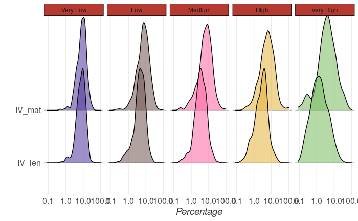

```r
ggplot(mar_tidy[grepl("IV_",mar_tidy$name),], aes(x = (value), y = name,fill=gm,alpha=0.6, height = stat(density))) +
  scale_fill_manual(name = "Marginalization", values = c("High" = altoc, "Low" = bajoc, "Medium" = medioc, "Very High" = maltoc, "Very Low" = mbajoc),
                        labels = c("Very Low", "Low", "Medium", "High", "Very High"))+
    geom_density_ridges(stat = "density")+
  scale_x_log10(name="Percentage")+
  scale_y_discrete(name=" ")+
    th+
    theme(
      axis.text.x = element_text(angle = 0),
      panel.grid.minor = element_blank(),
      legend.position = "none")+
    facet_grid(~gm)+
    theme(strip.background = element_rect(fill="#b53a31"))
ggsave("../../figs/ridges_marg_IV.png",height = 15, width = 30, units = "cm")
```

Use the Fligner-Killen median test to compare the homogeneity of variances

```r
tocomp <- mar_scores %>%
  group_by(gm) %>%
  select(gm,I_len,I_mat,IV_len,IV_mat)
logss <- sapply(tocomp %>% ungroup(gm) %>% select(-gm), function(x) log10(as.numeric(x)) )
tocomp[2:5] <- logss
tocomp <- tocomp[apply(tocomp %>% ungroup(gm) %>% select(-gm), 1, function(row) all(is.finite(row))),]
# tocomp <- tocomp %>% sample_n(300,replace = F)

tocomp %>%
  group_by(gm) %>%
  summarise(pval = fligner.test(IV_len,IV_mat,alternative="t")$p.value)
```

| gm | pval |
| --- | --- |
| Very Low | 1.533156e-36 |
| Low | 5.196049e-35 |
| Medium | 7.389215e-35 |
| High | 5.332814e-11 |
| Very High | 2.545150e-01 |

## But what about school type

```r
mar_tidy <- mar_scores %>% pivot_longer(c(I_len,II_len,III_len,IV_len,I_mat,II_mat,III_mat,IV_mat)) %>% unique()
```

```r
mar_scores %<>% left_join(schools %>% select(CLAVE,tipo_escuela),by="CLAVE") %>% unique()
mar_tidy2 <- mar_scores %>% pivot_longer(c(I_len,II_len,III_len,IV_len,I_mat,II_mat,III_mat,IV_mat)) %>% unique()
ggplot(mar_tidy2[grepl("I_",mar_tidy2$name),], aes(x = (value), y = name,fill=tipo_escuela,alpha=0.6, height = stat(density))) +
  # scale_fill_manual(name = "Marginalization", values = c("High" = altoc, "Low" = bajoc, "Medium" = medioc, "Very High" = maltoc, "Very Low" = mbajoc),
  #                       labels = c("Very Low", "Low", "Medium", "High", "Very High"))+
    geom_density_ridges(stat = "density")+
  scale_x_log10()+
    th+
    theme(
      axis.text.x = element_text(angle = 0),
      panel.grid.minor = element_blank(),
      legend.position = "none")+
    facet_grid(~tipo_escuela)+
    theme(strip.background = element_rect(fill="#b53a31"))
```

# Let’s check the Bayesian networks

# Puerto Morelos became municipality in 2011

```r
encode_ordinal <- function(x, order = unique(x)) {
  x <- as.numeric(factor(x, levels = order, exclude = NULL))
  x
}
```

```r
schools <- schools %>% select(-ovsd,-ovsdse,-ind0a100)
schools <- schools[complete.cases(schools),]
areas_df <- areas_df %>% mutate(CLAVE=CVEGEO) %>% select(-CVEGEO)
indig
```

```r
for_bn <- schools %>% left_join(indig %>% select(CLAVE,IPOB_INDI,IPhli))
for_bn <- for_bn %>% mutate(p_indig = IPOB_INDI/pop_marg,lang_indig=IPhli/IPOB_INDI)
for_bn %<>% left_join(areas_df,by="CLAVE")

for_bn[!complete.cases(for_bn),]$IPOB_INDI <- 0
for_bn[!complete.cases(for_bn),]$p_indig <- 0
databn <- for_bn %>% ungroup(CLAVE,NOM_ENT) %>% select(I_porc_len,II_porc_len,III_porc_len,IV_porc_len,I_porc_mat,II_porc_mat,III_porc_mat,IV_porc_mat,turno,gm,tipo_escuela,illiteracy,elementary,no_sewage,no_electricity,no_water,overcrowding,dirt_floor,less_5k,less_2minwage,im,lugar,lugarest,IPOB_INDI,p_indig,area,num,density,lang_indig)
databn

# I should automate this
databn$turno <- encode_ordinal(databn$turno)
databn$gm <- encode_ordinal(databn$gm)
databn$tipo_escuela <- encode_ordinal(databn$tipo_escuela)

# databn$turno <- as.double(databn$turno)
# databn$gm <- as.double(databn$gm)
# databn$num <- as.double(databn$num)
# databn$tipo_escuela <- as.double(databn$tipo_escuela)

databn2 <- databn

databn$I_porc_len <- log10(databn$I_porc_len)
databn$II_porc_len <- log10(databn$II_porc_len)
databn$III_porc_len <- log10(databn$III_porc_len)
databn$IV_porc_len <- log10(databn$IV_porc_len)

databn$I_porc_mat <- log10(databn$I_porc_mat)
databn$II_porc_mat <- log10(databn$II_porc_mat)
databn$III_porc_mat <- log10(databn$III_porc_mat)
databn$IV_porc_mat <- log10(databn$IV_porc_mat)

databn$density <- log10(databn$density)
databn$p_indig <- log10(databn$p_indig)
databn$lang_indig <- log10(databn$lang_indig)

databn_finite <- databn[apply(databn, 1, function(row) all(is.finite(row))),]
databn_finite <- databn[apply(databn %>% select(-turno,-gm,-num,-tipo_escuela), 1, function(row) all(is.finite(row))),]
databn_finite %<>% select(-im,-lugar,-lugarest,-IPOB_INDI,-area,-num)
```

Delete the highly correlated variables

```r
set.seed(42)
corrM <- cor(databn_finite[,c(9:22)])
highlyCorrelated <- findCorrelation(corrM, cutoff=0.50)
colnames(databn_finite[,c(9:22)])[highlyCorrelated]
databn_finite %<>% select(-illiteracy,-elementary,-less_2minwage,-dirt_floor,-less_5k)
databn_finite %<>% select(-gm)
```

# Variable selection

```r
# control <- trainControl(method="cv", number=10)
# model <- caret::train(I_porc_len~., data=databn_finite, method="cforest", preProcess="scale", trControl=control)
# # estimate variable importance
# importance <- varImp(model, scale=FALSE)
# # summarize importance
# print(importance)
# # plot importance
# plot(importance)
```

```r
# set.seed(42)
# databn_finite2 <- as.data.frame(databn_finite)
# #Controlling the feature selection, using default functions, with 10 folds cross validation
# control <- rfeControl(functions=rfFuncs, method="cv", number=10)
# # run the RFE algorithm
# # using recursive feature elimination or backwards selection
# # let's check first if it works the same for each level and test
# results <- rfe(x=databn_finite2[,c(1,10:19)], y=databn_finite2[,2], rfeControl=control)
# # results <- rfe(databn[,c(1,10:27)], databn[,n], sizes=c(1:18), rfeControl=control)
# # summarize the results
# print(results)
# # list the chosen features
# predictors(results)
# # plot the results
# plot(results, type=c("g", "o"))
```

I haven’t figured how to save this graphs with the chunk output inline in a notebook, so we have to dissable it to run and save the plots

```r
for (i in 1:7){
  bnf <- bnlearn::h2pc(databn_finite[,c(i,9:17)])
  png(paste0("/figs/graph_",i,".png"))
  plot(graphviz.plot(bnf, shape = "ellipse"))
  dev.off()
  str.diff <- bnlearn::boot.strength(databn_finite[,c(i,9:17)],R=20,algorithm="h2pc")
  avg.diff <- averaged.network(str.diff)#,threshold = 0.7)
  png(paste0("/figs/graph_",i,"_boots.png"))
  plot(graphviz.plot(avg.diff, shape = "ellipse"))
  dev.off()
}
```

```r
bnf <- bnlearn::h2pc(databn_finite[,c(1,9:17)])
  str.diff <- bnlearn::boot.strength(databn_finite[,c(1,9:17)],R=20,algorithm="h2pc")
  avg.diff <- averaged.network(str.diff)#,threshold = 0.7)
  plot(graphviz.plot(avg.diff, shape = "ellipse"))
```

```r
bnf <- bnlearn::h2pc(databn_finite[,c(1,9:17)])
fitted <- bn.fit(bnf,databn_finite[,c(1,9:17)])
```

```r
graphviz.plot(bnf, shape = "ellipse")
```

```r
fitted
```

```
  Bayesian network parameters

  Parameters of node IV_porc_len (Gaussian distribution)

Conditional density: IV_porc_len | turno + tipo_escuela + overcrowding + density
Coefficients:
 (Intercept)         turno  tipo_escuela  overcrowding       density
 0.959584307  -0.049579922   0.082062367  -0.007839133   0.038400757
Standard deviation of the residuals: 0.3225513

  Parameters of node turno (Gaussian distribution)

Conditional density: turno | tipo_escuela + no_water
Coefficients:
 (Intercept)  tipo_escuela      no_water
 1.457507595  -0.069703101  -0.005509427
Standard deviation of the residuals: 0.6023956

  Parameters of node tipo_escuela (Gaussian distribution)

Conditional density: tipo_escuela | no_water
Coefficients:
(Intercept)     no_water
3.016563264  0.007865988
Standard deviation of the residuals: 1.605212

  Parameters of node no_sewage (Gaussian distribution)

Conditional density: no_sewage | overcrowding
Coefficients:
 (Intercept)  overcrowding
  -3.5899777     0.2001326
Standard deviation of the residuals: 3.575512

  Parameters of node no_electricity (Gaussian distribution)

Conditional density: no_electricity | no_sewage + no_water
Coefficients:
(Intercept)    no_sewage     no_water
 0.03559482   0.19572710   0.07582562
```

[output cut: 26 more lines]

```
  Parameters of node density (Gaussian distribution)

Conditional density: density | no_sewage + no_electricity + overcrowding + lang_indig
Coefficients:
   (Intercept)       no_sewage  no_electricity    overcrowding      lang_indig
   -0.66884068     -0.02683626     -0.03843854     -0.01980153     -0.90516189
Standard deviation of the residuals: 0.6657236

  Parameters of node lang_indig (Gaussian distribution)

Conditional density: lang_indig | no_electricity
Coefficients:
   (Intercept)  no_electricity
    -0.3915927       0.0110290
Standard deviation of the residuals: 0.08323559
```

```r
graphviz.plot(bnf, shape = "ellipse")
```

```r
bnf <- bnlearn::h2pc(databn_finite[,c(5,9:17)])
bnf <- bnlearn::reverse.arc(bnf,from="tipo_escuela",to="I_porc_mat")
bnf <- bnlearn::reverse.arc(bnf,from="turno",to="I_porc_mat")
bnf <- bnlearn::reverse.arc(bnf,from="overcrowding",to="I_porc_mat")
bnf <- bnlearn::reverse.arc(bnf,from="lang_indig",to="I_porc_mat")
fitted <- bn.fit(bnf,databn_finite[,c(5,9:17)])
```

```r
graphviz.plot(bnf, shape = "ellipse")
```

```r
bnf <- bnlearn::h2pc(databn_finite[,c(8,9:17)])
bnf <- bnlearn::reverse.arc(bnf,from="tipo_escuela",to="IV_porc_mat")
bnf <- bnlearn::reverse.arc(bnf,from="turno",to="IV_porc_mat")
fitted <- bn.fit(bnf,databn_finite[,c(8,9:17)])
```

```r
graphviz.plot(bnf, shape = "ellipse")
```